# Plotting Data 2

# Exercise 6: Bar Plot Madness

## 6(a) Color and Stacking Madness

- Change the following plot so that it shows *proportion* on the y-axis, not count.
- Change the x-axis so that it doesn’t appear to be continuous.
  - Hint: Transform the variable!
- Also change the colors of the bar fills, as well as the lines.
- Put the bars for transmission side-by-side with their own colour.
- Capitalize the legend title.

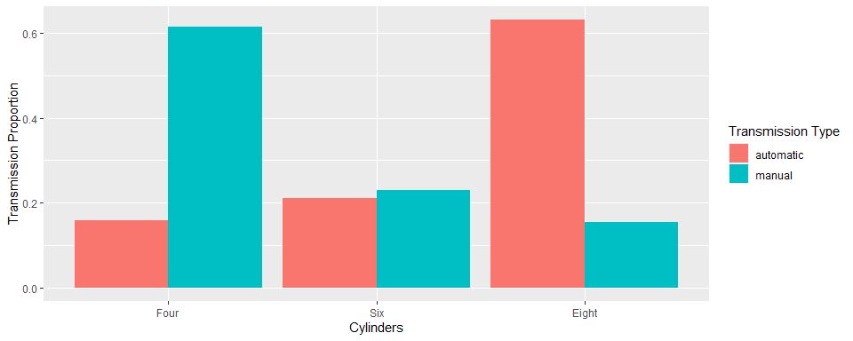

```r
mtcars %>%
  mutate(transmission = if_else(am == 0, "automatic", "manual")) %>%
  mutate(cyl = recode(mtcars$cyl, `4` = "Four", `6` = "Six", `8` = "Eight")) %>%
  ggplot(aes(cyl, ..prop.., group = transmission, fill = transmission)) +
  geom_bar(position = "dodge") +
  scale_x_discrete("Cylinders", limits = c("Four","Six","Eight")) +
  ylab("Transmission Proportion") +
  labs(fill = "Transmission Type")
```

## 6(b) Bar Heights Already Calculated

Here’s the number of people having a certain hair colour from a sample of 592 people:

```r
(hair <- as_tibble(HairEyeColor) %>%
  count(Hair, wt = n))
```

```
## # A tibble: 4 x 2
##   Hair      n
##   <chr> <dbl>
## 1 Black   108
## 2 Blond   127
## 3 Brown   286
## 4 Red      71
```

Fix the following bar plot so that it shows these counts.

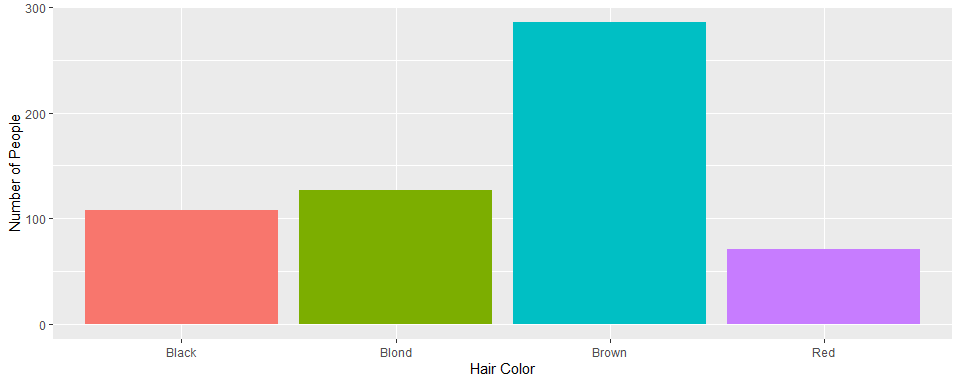

```r
ggplot(hair, aes(Hair, n, fill = Hair)) +
  geom_bar(stat = "identity") +
  guides(fill = FALSE) +
  xlab("Hair Color") +
  ylab("Number of People")
```

# Exercise 7: Tiling

Here’s the number of people having a certain hair and eye colour from a sample of 592 people:

```r
(hair_eye <- as_tibble(HairEyeColor) %>%
  count(Hair, Eye, wt = n))
```

```
## # A tibble: 16 x 3
##    Hair  Eye       n
##    <chr> <chr> <dbl>
##  1 Black Blue     20
##  2 Black Brown    68
##  3 Black Green     5
##  4 Black Hazel    15
##  5 Blond Blue     94
##  6 Blond Brown     7
##  7 Blond Green    16
##  8 Blond Hazel    10
##  9 Brown Blue     84
## 10 Brown Brown   119
## 11 Brown Green    29
## 12 Brown Hazel    54
## 13 Red   Blue     17
## 14 Red   Brown    26
## 15 Red   Green    14
## 16 Red   Hazel    14
```

Fix the following plot so that it shows a filled-in square for each combination. *Hint:* What’s the title of this exercise?

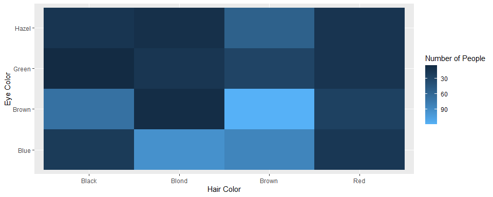

```r
ggplot(hair_eye, aes(Hair, Eye)) +
  geom_tile(aes(fill = n)) +
  guides(fill = guide_colorbar(reverse = TRUE)) +
  xlab("Hair Color") +
  ylab("Eye Color") +
  labs(fill = "Number of People")
```

By the way, `geom_count()` is like `geom_bar()`: it counts the number of overlapping points.

# Additional Take-Home Practice

If you’d like some practice, give these exercises a try

**Exercise 1**: Make a plot of `year` (x) vs `lifeExp` (y), with points coloured by continent. Then, to that same plot, fit a straight regression line to each continent, without the error bars. If you can, try piping the data frame into the `ggplot()` function.

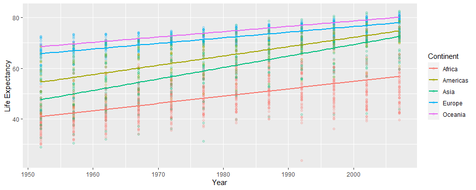

```r
gapminder %>%
  ggplot(aes(year, lifeExp, color = continent)) +
  geom_point(alpha = 0.2) +
  geom_smooth(method = "lm", se = FALSE) +
  xlab("Year") +
  ylab("Life Expectancy") +
  labs(color = "Continent")
```

**Exercise 2**: Repeat Exercise 1, but switch the *regression line* and *geom_point* layers. How is this plot different from that of Exercise 1?

Now, the points are on top of the regression line.

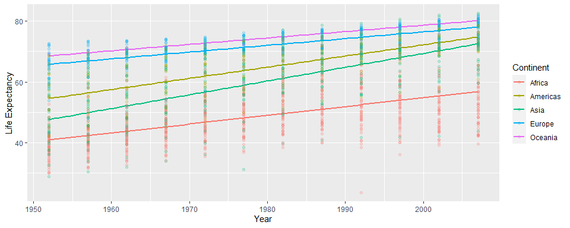

```r
gapminder %>%
  ggplot(aes(year, lifeExp, color = continent)) +
  geom_smooth(method = "lm", se = FALSE) +
  geom_point(alpha = 0.2) +
  xlab("Year") +
  ylab("Life Expectancy") +
  labs(color = "Continent")
```

**Exercise 3**: Omit the `geom_point()` layer from either of the above two plots (it doesn’t matter which). Does the line still show up, even though the data aren’t shown? Why or why not?

The regression lines are still visible - their presence is depedent on the aesthetic mappings and on geom_smooth, not on the points.

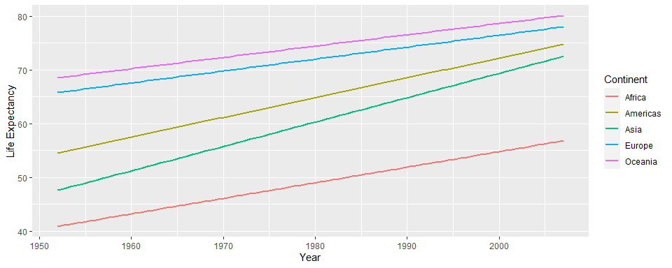

```r
gapminder %>%
  ggplot(aes(year, lifeExp, color = continent)) +
  geom_smooth(method = "lm", se = FALSE) +
  xlab("Year") +
  ylab("Life Expectancy") +
  labs(color = "Continent")
```

**Exercise 4**: Make a plot of `year` (x) vs `lifeExp` (y), facetted by continent. Then, fit a smoother through the data for each continent, without the error bars. Choose a span that you feel is appropriate.

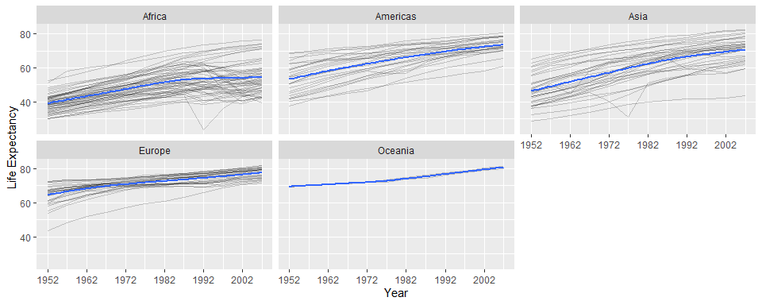

```r
gapminder %>%
  ggplot(aes(year, lifeExp)) +
  geom_line(aes(group = country), alpha = 0.2) +
  geom_smooth(se = FALSE) +
  facet_wrap(vars(continent)) +
  scale_x_continuous("Year", breaks = seq(1952, 2007, by = 10)) +
  ylab("Life Expectancy")
```

**Exercise 5**: Plot the population over time (year) using lines, so that each country has its own line. Colour by `gdpPercap`. Add alpha transparency to your liking.

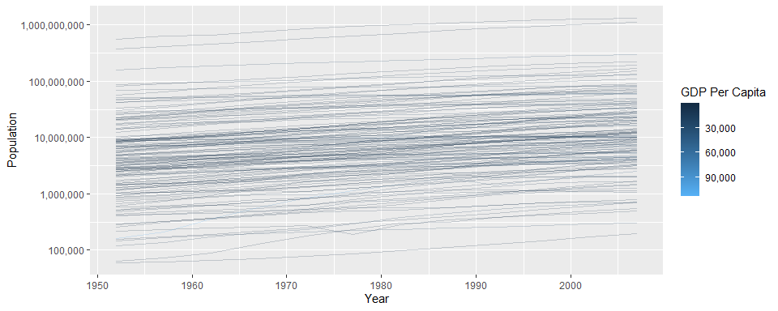

```r
gapminder %>%
  ggplot(aes(year, pop)) +
  geom_line(aes(group = country, color = gdpPercap), alpha = 0.2) +
  scale_y_log10("Population", labels = scales::comma_format()) +
  scale_color_continuous("GDP Per Capita", labels = scales::comma_format()) +
  xlab("Year") +
  guides(color = guide_colorbar(reverse = TRUE))
```

**Exercise 6**: Add points to the plot in Exercise 5.

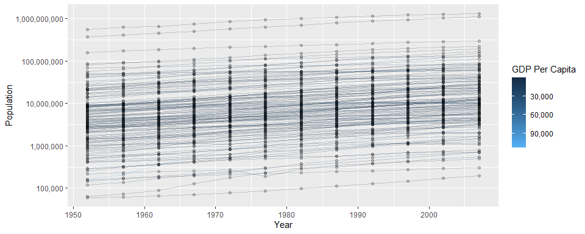

```r
gapminder %>%
  ggplot(aes(year, pop)) +
  geom_point(alpha = 0.2) +
  geom_line(aes(group = country, color = gdpPercap), alpha = 0.2) +
  scale_y_log10("Population", labels = scales::comma_format()) +
  scale_color_continuous("GDP Per Capita", labels = scales::comma_format()) +
  xlab("Year") +
  guides(color = guide_colorbar(reverse = TRUE))
```